# Project 3

Yuhan Xiao

2023-10-22

## Background

```r
library(here)
library(tidyverse)
library(lubridate)
library(ggplot2)
library(tidytext)
library(wordcloud)
```

#### Load data

```r
rds_files <- c("b_lyrics.RDS", "ts_lyrics.RDS", "sales.RDS")
## Check whether we have all 3 files
if (any(!file.exists(here("data", rds_files)))) {
    ## If we don't, then download the data
    b_lyrics <- readr::read_csv("https://raw.githubusercontent.com/rfordatascience/tidytuesday/master/data/2020/2020-09-29/beyonce_lyrics.csv")
    ts_lyrics <- readr::read_csv("https://raw.githubusercontent.com/rfordatascience/tidytuesday/master/data/2020/2020-09-29/taylor_swift_lyrics.csv")
    sales <- readr::read_csv("https://raw.githubusercontent.com/rfordatascience/tidytuesday/master/data/2020/2020-09-29/sales.csv")

    ## Then save the data objects to RDS files
    saveRDS(b_lyrics, file = here("data", "b_lyrics.RDS"))
    saveRDS(ts_lyrics, file = here("data", "ts_lyrics.RDS"))
    saveRDS(sales, file = here("data", "sales.RDS"))
}

# load the datasets
b_lyrics <- readRDS(here("data", "b_lyrics.RDS"))
ts_lyrics <- readRDS(here("data", "ts_lyrics.RDS"))
sales <- readRDS(here("data", "sales.RDS"))
```

## Part 1: Explore album sales

In this section, the goal is to explore the sales of studio albums from Beyoncé and Taylor Swift.

**Notes**

- In each of the subsections below that ask you to create a plot, you must create a title, subtitle, x-axis label, and y-axis label with units where applicable. For example, if your axis says “sales” as an axis label, change it to “sales (in millions)”.

#### Part 1A

In this section, we will do some data wrangling.

1. Use `lubridate` to create a column called `released` that is a `Date` class. However, to be able to do this, you first need to use `stringr` to search for pattern that matches things like this “(US)[51]” in a string like this “September 1, 2006 (US)[51]” and removes them. (**Note**: to get full credit, you must create the regular expression).
2. Use `forcats` to create a factor called country (**Note**: you may need to collapse some factor levels).
3. Transform the `sales` into a unit that is album sales in millions of dollars.
4. Keep only album sales from the UK, the US or the World.
5. Auto print your final wrangled tibble data frame.

```r
pattern = "\\s\\(\\w+\\)\\[\\d+\\]"
sales_wrangled <- sales %>%
  mutate(released = str_replace(released, pattern, "")) %>%
  mutate(released = mdy(released)) %>%
  mutate(country = as.factor(country)) %>%
  mutate(country = fct_collapse(country, "FRA" = c("FR", "FRA"),
         "WW" = c("World", "WW"))) %>%
  mutate(sales = sales/1000000) %>%
  filter(country %in% c("UK", "US", "WW"))

sales_wrangled
```

```
## # A tibble: 36 × 8
##    artist       title        country  sales released   re_release  label formats
##    <chr>        <chr>        <fct>    <dbl> <date>     <chr>       <chr> <chr>
##  1 Taylor Swift Taylor Swift US       5.72  2006-10-24 March 18, … Big … CD, CD…
##  2 Taylor Swift Fearless     WW      12     2008-11-11 October 27… Big … CD, CD…
##  3 Taylor Swift Fearless     US       7.18  2008-11-11 October 27… Big … CD, CD…
##  4 Taylor Swift Fearless     UK       0.609 2008-11-11 October 27… Big … CD, CD…
##  5 Taylor Swift Speak Now    WW       5     2010-10-25 <NA>        Big … CD, CD…
##  6 Taylor Swift Speak Now    US       4.69  2010-10-25 <NA>        Big … CD, CD…
##  7 Taylor Swift Speak Now    UK       0.169 2010-10-25 <NA>        Big … CD, CD…
##  8 Taylor Swift Red          WW       6     2012-10-22 <NA>        Big … CD, CD…
##  9 Taylor Swift Red          US       4.46  2012-10-22 <NA>        Big … CD, CD…
## 10 Taylor Swift Red          UK       0.693 2012-10-22 <NA>        Big … CD, CD…
## # ℹ 26 more rows
```

#### Part 1B

In this section, we will do some more data wrangling followed by summarization using wrangled data from Part 1A.

1. Keep only album sales from the US.
2. Create a new column called `years_since_release` corresponding to the number of years since the release of each album from Beyoncé and Taylor Swift. This should be a whole number and you should round down to “14” if you get a non-whole number like “14.12” years. (**Hint**: you may find the `interval()` function from `lubridate` helpful here, but this not the only way to do this.)
3. Calculate the most recent, oldest, and the median years since albums were released for both Beyoncé and Taylor Swift.

```r
sales_summ <- sales_wrangled %>%
  select(country, released, artist) %>%
  filter(country == "US") %>%
  mutate(years_since_release = floor(as.duration(interval(released, today())) / dyears(1))) %>%
  group_by(artist) %>%
  summarise(
    most_recent_years = min(years_since_release),
    oldest_years = max(years_since_release),
    median_years = median(years_since_release)
  )

sales_summ
```

```
## # A tibble: 2 × 4
##   artist       most_recent_years oldest_years median_years
##   <chr>                    <dbl>        <dbl>        <dbl>
## 1 Beyoncé                      7           20           13
## 2 Taylor Swift                 4           16           10
```

#### Part 1C

Using the wrangled data from Part 1A:

1. Calculate the total album sales for each `artist` and for each `country` (only sales from the UK, US, and World).
2. Using the total album sales, create a percent stacked barchart using `ggplot2` of the percentage of sales of studio albums (in millions) along the y-axis for the two artists along the x-axis colored by the `country`.

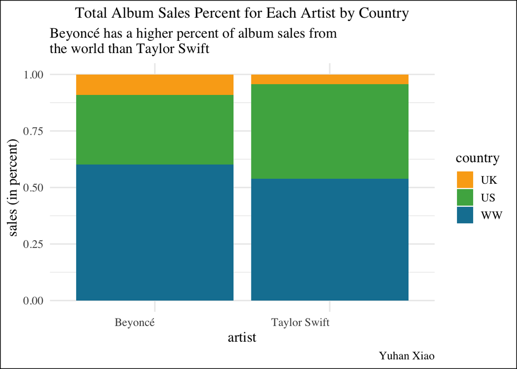

```r
sales_total <- sales_wrangled %>%
  select(artist, country, sales) %>%
  filter(country %in% c("UK", "US", "WW")) %>%
  group_by(artist, country) %>%
  summarise(
    total_sales = sum(sales)
  )

sales_total %>% ggplot(aes(fill=country, y=total_sales, x=artist)) +
  geom_bar(position="fill", stat="identity") +
  scale_fill_manual(values = c("#FAAB18", "#4CAF50", "#1380A1")) +
  labs(title = "Total Album Sales Percent for Each Artist by Country", subtitle = str_wrap("Beyoncé has a higher percent of album sales from the world than Taylor Swift", 50), caption = "Yuhan Xiao", x = "artist", y = "sales (in percent)", fill = "country") +
  theme_minimal(base_size = 14) +
  theme(plot.title = element_text(hjust = 0.5, vjust = 1, size = 15),
        axis.text.x = element_text(angle = 0, hjust = 1),
        plot.background = element_rect(fill = "white"),
        text = element_text(family = "Times"))
```

#### Part 1D

Using the wrangled data from Part 1A, use `ggplot2` to create a bar plot for the sales of studio albums (in millions) along the x-axis for each of the album titles along the y-axis.

**Note**:

- You only need to consider the global World sales (you can ignore US and UK sales for this part).
- The title of the album must be clearly readable along the y-axis.
- Each bar should be colored by which artist made that album.
- The bars should be ordered from albums with the most sales (top) to the least sales (bottom) (**Note**: you must use functions from `forcats` for this step).

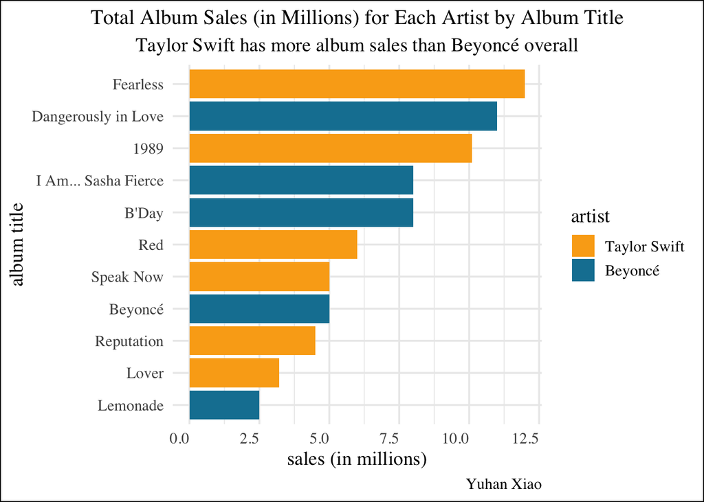

```r
sales_wrangled %>%
  select(sales, artist, title, country) %>%
  filter(country == "WW") %>%
  ggplot(aes(sales, fct_reorder(.f = title, .x = sales), fill = fct_reorder2(artist, sales, title))) +
    geom_bar(stat = "identity") +
    scale_fill_manual(values = c("#FAAB18", "#1380A1")) +
    labs(title = "Total Album Sales (in Millions) for Each Artist by Album Title", subtitle = str_wrap("Taylor Swift has more album sales than Beyoncé overall", 60), caption = "Yuhan Xiao", x = "sales (in millions)", y = "album title", fill = "artist") +
    theme_minimal(base_size = 14) +
    theme(plot.title = element_text(hjust = 0.5, vjust = 1, size = 15),
          plot.subtitle = element_text(hjust = 0.5),
          axis.text.x = element_text(angle = 0, hjust = 1),
          plot.background = element_rect(fill = "white"),
          text = element_text(family = "Times"))
```

#### Part 1E

Using the wrangled data from Part 1A, use `ggplot2` to create a scatter plot of sales of studio albums (in millions) along the y-axis by the released date for each album along the x-axis.

**Note**:

- The points should be colored by the artist.
- There should be three scatter plots (one for UK, US and world sales) faceted by rows.

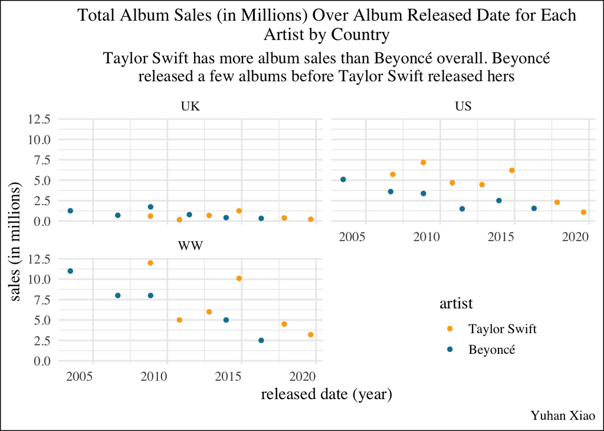

```r
sales_wrangled %>%
  select(sales, released, artist, country) %>%
  ggplot(aes(released, sales, color = fct_reorder2(artist, sales, released))) +
    facet_wrap(~country, nrow=2, scales="fixed") +
    geom_point() +
    scale_color_manual(values = c("#FAAB18", "#1380A1")) +
    labs(title = str_wrap("Total Album Sales (in Millions) Over Album Released Date for Each Artist by Country", 70), subtitle = str_wrap("Taylor Swift has more album sales than Beyoncé overall. Beyoncé released a few albums before Taylor Swift released hers", 70), caption = "Yuhan Xiao", x = "released date (year)", y = "sales (in millions)", color = "artist") +
    theme_minimal(base_size = 14) +
    theme(plot.title = element_text(hjust = 0.5, vjust = 1, size = 15),
          plot.subtitle = element_text(hjust = 0.5),
          axis.text.x = element_text(angle = 0, hjust = 1),
          plot.background = element_rect(fill = "white"),
          text = element_text(family = "Times"),
          legend.position = c(0.8, 0.15))
```

## Part 2: Exploring sentiment of lyrics

In Part 2, we will explore the lyrics in the `b_lyrics` and `ts_lyrics` datasets.

#### Part 2A

Using `ts_lyrics`, create a new column called `line` with one line containing the character string for each line of Taylor Swift’s songs.

- How many lines in Taylor Swift’s lyrics contain the word “hello”? For full credit, show all the rows in `ts_lyrics` that have “hello” in the `line` column and report how many rows there are in total.
- How many lines in Taylor Swift’s lyrics contain the word “goodbye”? For full credit, show all the rows in `ts_lyrics` that have “goodbye” in the `line` column and report how many rows there are in total.

```r
ts_lyrics_line <- ts_lyrics %>%
  unnest_tokens(
    output = line,
    input = Lyrics,
    token = "lines"
  )

pattern = "hello"
ts_lyrics_line %>%
  select(Artist, line) %>%
  filter(grepl(pattern, line)) %>%
  mutate(nrow = n())
```

```
## # A tibble: 6 × 3
##   Artist       line                                  nrow
##   <chr>        <chr>                                <int>
## 1 Taylor Swift "and say, \"hello\""                     6
## 2 Taylor Swift "that i can't say \"hello\" to you"      6
## 3 Taylor Swift "'cause all i know is we said hello"     6
## 4 Taylor Swift "'cause all i know is we said hello"     6
## 5 Taylor Swift "all i know is we said hello"            6
## 6 Taylor Swift "all i know is we said hello"            6
```

```r
pattern = "goodbye"
ts_lyrics_line %>%
  select(Artist, line) %>%
  filter(grepl(pattern, line)) %>%
  mutate(nrow = n())
```

```
## # A tibble: 12 × 3
##    Artist       line                                                        nrow
##    <chr>        <chr>                                                      <int>
##  1 Taylor Swift "goodbye, baby"                                               12
##  2 Taylor Swift "braced myself for the goodbye,"                              12
##  3 Taylor Swift "you gave me all your love and all i gave you was goodbye"    12
##  4 Taylor Swift "and force us into a goodbye"                                 12
##  5 Taylor Swift "and risk another goodbye"                                    12
##  6 Taylor Swift "stumbled through the long goodbye"                           12
##  7 Taylor Swift "but people like me are gone forever when you say goodbye"    12
##  8 Taylor Swift "said goodbye in "                                            12
##  9 Taylor Swift "said goodbye in "                                            12
## 10 Taylor Swift "saying goodbye is death by a thousand cuts"                  12
## 11 Taylor Swift "'cause saying goodbye is death by a thousand cuts"           12
## 12 Taylor Swift "i'll tell you truth, but never, \"goodbye\""                 12
```

#### Part 2B

Repeat the same analysis for b_lyrics as described in Part 2A.

```r
pattern = "hello"
b_lyrics %>%
  select(artist_name, line) %>%
  filter(grepl(pattern, line)) %>%
  mutate(nrow = n())
```

```
## # A tibble: 32 × 3
##    artist_name line                                          nrow
##    <chr>       <chr>                                        <int>
##  1 Beyoncé     Fellow great Americans, hello                   32
##  2 Beyoncé     You had me at hello (Hello)                     32
##  3 Beyoncé     You had me at hello (Hello)                     32
##  4 Beyoncé     'Cause you had me at hello (My cool) (Hello)    32
##  5 Beyoncé     You had me at hello (Hello)                     32
##  6 Beyoncé     You had me at hello (Hello)                     32
##  7 Beyoncé     You had me at hello (Hello)                     32
##  8 Beyoncé     Hello (Hello, hello)                            32
##  9 Beyoncé     You had me at hello (Hello)                     32
## 10 Beyoncé     You had me at hello (Hello)                     32
## # ℹ 22 more rows
```

```r
pattern = "goodbye"
b_lyrics %>%
  select(artist_name, line) %>%
  filter(grepl(pattern, line)) %>%
  mutate(nrow = n())
```

```
## # A tibble: 12 × 3
##    artist_name line                                                     nrow
##    <chr>       <chr>                                                   <int>
##  1 Beyoncé     We only said goodbye with words                            12
##  2 Beyoncé     We only said goodbye with words                            12
##  3 Beyoncé     We only said goodbye with words                            12
##  4 Beyoncé     Thank God, I found the good in goodbye                     12
##  5 Beyoncé     Thank God, I found the good in goodbye                     12
##  6 Beyoncé     Thank God, I found the good in goodbye                     12
##  7 Beyoncé     It's so hard to say goodbye                                12
##  8 Beyoncé     I never want to say goodbye                                12
##  9 Beyoncé     I never, ever want to say goodbye                          12
## 10 Beyoncé     We've got to say goodbye                                   12
## 11 Beyoncé     Don't have to say goodbye                                  12
## 12 Beyoncé     Somewhere between hi and goodbye, I felt so comfortable    12
```

#### Part 2C

Using the `b_lyrics` dataset,

1. Tokenize each lyrical line by words.
2. Remove the “stopwords”.
3. Calculate the total number for each word in the lyrics.
4. Using the “bing” sentiment lexicon, add a column to the summarized data frame adding the “bing” sentiment lexicon.
5. Sort the rows from most frequent to least frequent words.
6. Only keep the top 25 most frequent words.
7. Auto print the wrangled tibble data frame.
8. Use `ggplot2` to create a bar plot with the top words on the y-axis and the frequency of each word on the x-axis. Color each bar by the sentiment of each word from the “bing” sentiment lexicon. Bars should be ordered from most frequent on the top to least frequent on the bottom of the plot.
9. Create a word cloud of the top 25 most frequent words.

```r
b_top_25_freq_word <- b_lyrics %>%
  unnest_tokens(
    output = word,
    input = line
  ) %>%
  anti_join(stop_words) %>%
  count(word, sort = TRUE) %>%
  inner_join(get_sentiments("bing")) %>%
  head(25)

b_top_25_freq_word
```

```
## # A tibble: 25 × 3
##    word          n sentiment
##    <chr>     <int> <chr>
##  1 love       1362 positive
##  2 crazy       308 negative
##  3 top         241 positive
##  4 bad         132 negative
##  5 beautiful   131 positive
##  6 whoa        121 positive
##  7 damn        106 negative
##  8 hurt         90 negative
##  9 hard         87 negative
## 10 ready        85 positive
## # ℹ 15 more rows
```

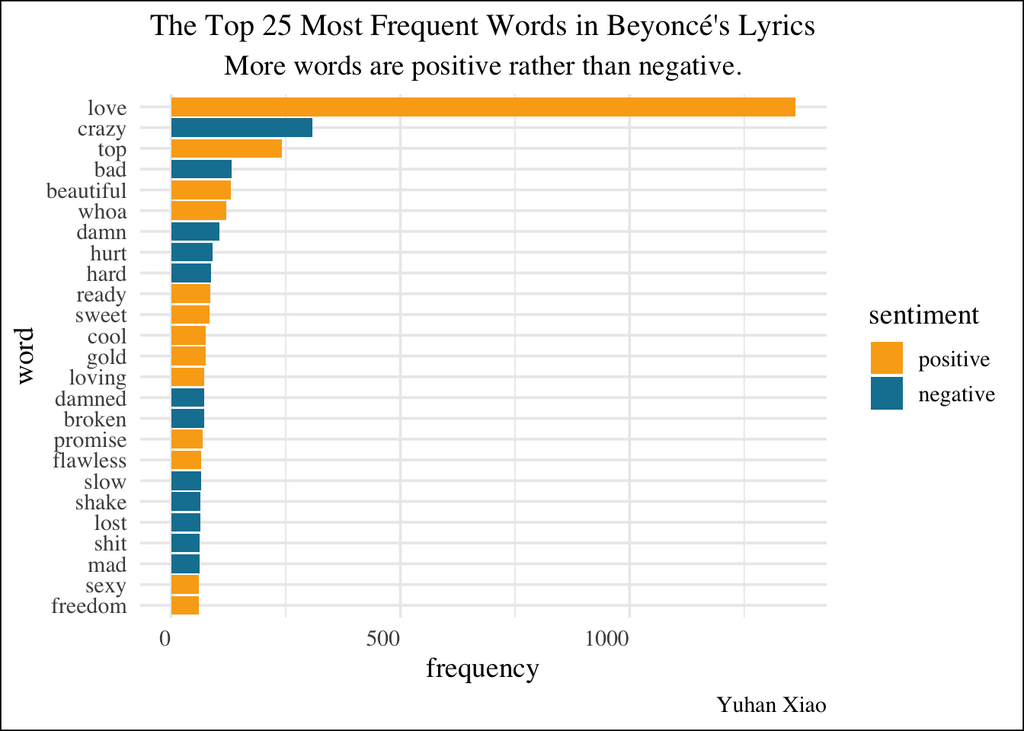

```r
b_top_25_freq_word %>%
  ggplot(aes(n, fct_reorder(.f = word, .x = n), fill = fct_reorder2(sentiment, word, n))) +
  geom_bar(stat = "identity") +
  scale_fill_manual(values = c("#FAAB18", "#1380A1")) +
  labs(title = str_wrap("The Top 25 Most Frequent Words in Beyoncé's Lyrics", 70), subtitle = str_wrap("More words are positive rather than negative.", 70), caption = "Yuhan Xiao", x = "frequency", y = "word", fill = "sentiment") +
  theme_minimal(base_size = 14) +
  theme(plot.title = element_text(hjust = 0.5, vjust = 1, size = 15),
        plot.subtitle = element_text(hjust = 0.5),
        axis.text.x = element_text(angle = 0, hjust = 1),
        plot.background = element_rect(fill = "white"),
        text = element_text(family = "Times"))
```

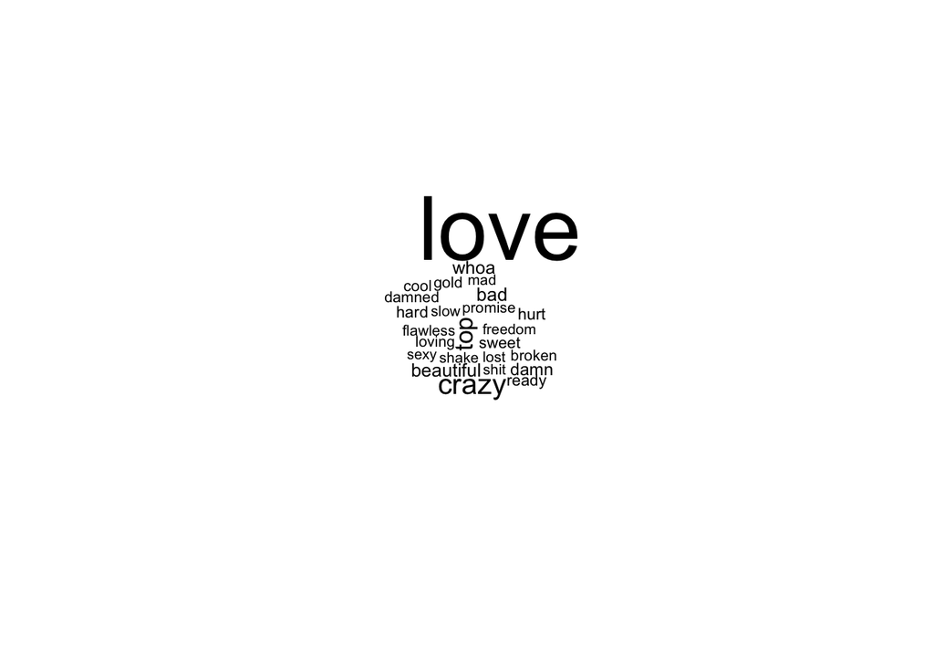

```r
b_top_25_freq_word %>%
  with(wordcloud(word, n))
```

#### Part 2D

Repeat the same analysis as above in Part 2C, but for `ts_lyrics`.

```r
ts_top_25_freq_word <- ts_lyrics_line %>%
  unnest_tokens(
    output = word,
    input = line
  ) %>%
  anti_join(stop_words) %>%
  count(word, sort = TRUE) %>%
  inner_join(get_sentiments("bing")) %>%
  head(25)

ts_top_25_freq_word
```

```
## # A tibble: 25 × 3
##    word          n sentiment
##    <chr>     <int> <chr>
##  1 love        248 positive
##  2 bad          80 negative
##  3 shake        73 negative
##  4 break        59 negative
##  5 mad          48 negative
##  6 beautiful    46 positive
##  7 smile        45 positive
##  8 hate         44 negative
##  9 fall         43 negative
## 10 whoa         36 positive
## # ℹ 15 more rows
```

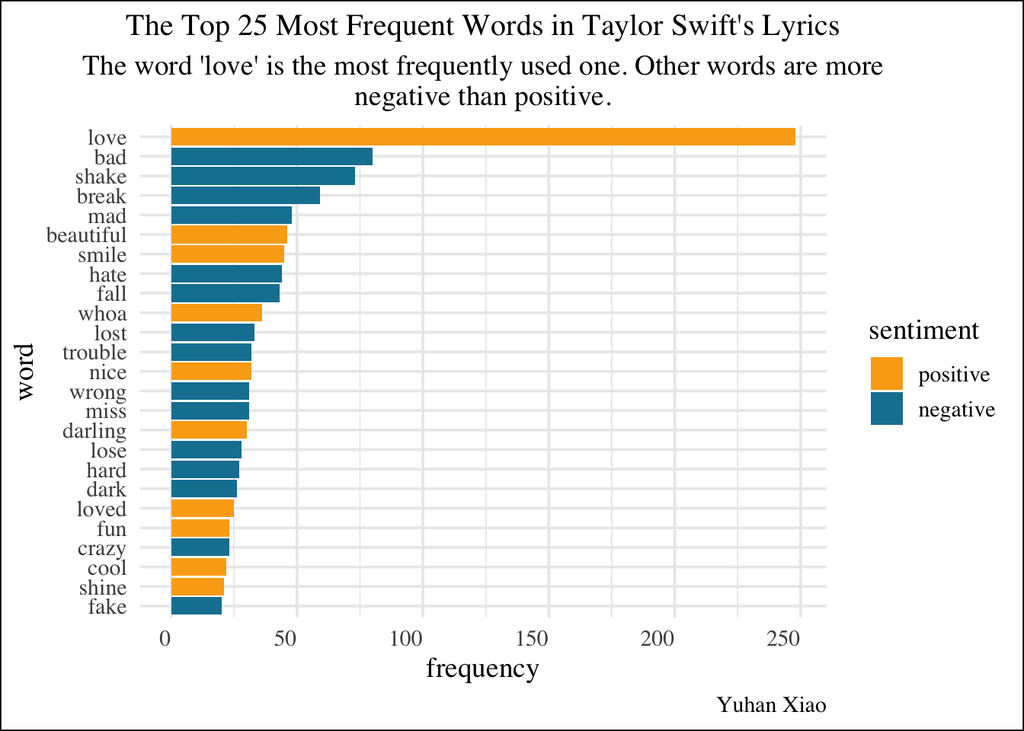

```r
ts_top_25_freq_word %>%
  ggplot(aes(n, fct_reorder(.f = word, .x = n), fill = fct_reorder2(sentiment, word, n))) +
  geom_bar(stat = "identity") +
  scale_fill_manual(values = c("#FAAB18", "#1380A1")) +
  labs(title = str_wrap("The Top 25 Most Frequent Words in Taylor Swift's Lyrics", 70), subtitle = str_wrap("The word 'love' is the most frequently used one. Other words are more negative than positive.", 70), caption = "Yuhan Xiao", x = "frequency", y = "word", fill = "sentiment") +
  theme_minimal(base_size = 14) +
  theme(plot.title = element_text(hjust = 0.5, vjust = 1, size = 15),
        plot.subtitle = element_text(hjust = 0.5),
        axis.text.x = element_text(angle = 0, hjust = 1),
        plot.background = element_rect(fill = "white"),
        text = element_text(family = "Times"))
```

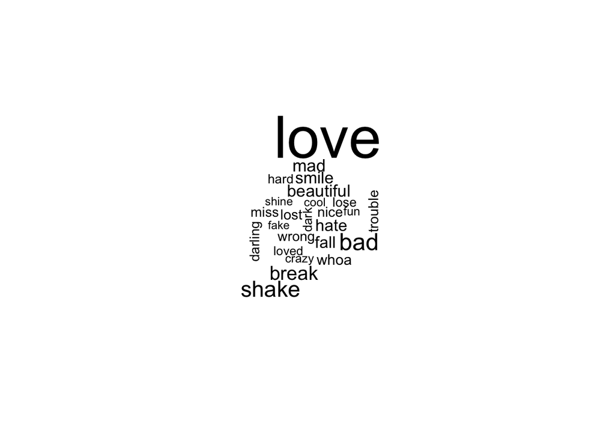

```r
ts_top_25_freq_word %>%
  with(wordcloud(word, n))
```

#### Part 2E

Using the `ts_lyrics` dataset,

1. Tokenize each lyrical line by words.
2. Remove the “stopwords”.
3. Calculate the total number for each word in the lyrics **for each Album**.
4. Using the “afinn” sentiment lexicon, add a column to the summarized data frame adding the “afinn” sentiment lexicon.
5. Calculate the average sentiment score **for each Album**.
6. Auto print the wrangled tibble data frame.
7. Join the wrangled data frame from Part 1A (album sales in millions) with the wrangled data frame from #6 above (average sentiment score for each album).
8. Using `ggplot2`, create a scatter plot of the average sentiment score for each album (y-axis) and the album release data along the x-axis. Make the size of each point the album sales in millions.
9. Add a horizontal line at y-intercept=0.
10. Write 2-3 sentences interpreting the plot answering the question “How has the sentiment of Taylor Swift’s albums have changed over time?”. Add a title, subtitle, and useful axis labels.

```r
ts_album_ss <- ts_lyrics_line %>%
  unnest_tokens(
    output = word,
    input = line
  ) %>%
  anti_join(stop_words) %>%
  group_by(Album) %>%
  count(word, sort = TRUE) %>%
  inner_join(get_sentiments("afinn")) %>%
  summarize(
    avg_sentiment = mean(value)
  ) %>%
  mutate(Album = tolower(Album))

ts_album_ss
```

```
## # A tibble: 8 × 2
##   Album        avg_sentiment
##   <chr>                <dbl>
## 1 1989              -0.822
## 2 fearless           0.0192
## 3 lover             -0.429
## 4 red               -0.00870
## 5 speak now         -0.365
## 6 taylor swift       0.137
## 7 folklore          -0.613
## 8 reputation        -0.495
```

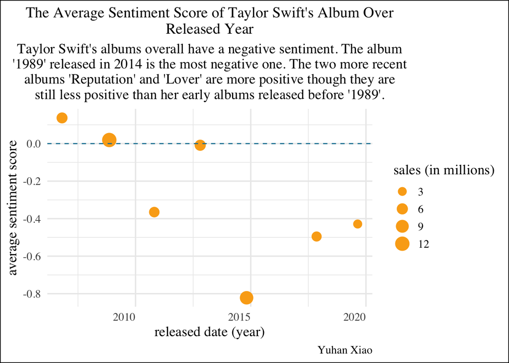

```r
sales_wrangled %>%
  rename(Album = title) %>%
  mutate(Album = tolower(Album)) %>%
  inner_join(ts_album_ss) %>%
  ggplot(aes(released, avg_sentiment, size = sales)) +
    geom_point(color = "#FAAB18") +
    geom_hline(yintercept = 0, linetype = "dashed", color = "#1380A1") +
    labs(title = str_wrap("The Average Sentiment Score of Taylor Swift's Album Over Released Year", 60), subtitle = str_wrap("Taylor Swift's albums overall have a negative sentiment. The album '1989' released in 2014 is the most negative one. The two more recent albums 'Reputation' and 'Lover' are more positive though they are still less positive than her early albums released before '1989'.", 70), caption = "Yuhan Xiao", x = "released date (year)", y = "average sentiment score", size = "sales (in millions)") +
    theme_minimal(base_size = 14) +
    theme(plot.title = element_text(hjust = 0.5, vjust = 1, size = 15),
          plot.subtitle = element_text(hjust = 0.5),
          axis.text.x = element_text(angle = 0, hjust = 1),
          plot.background = element_rect(fill = "white"),
          text = element_text(family = "Times"))
```